# Debug Article Titles

Ian and Chris

02/23/2022

## Introduction

Chris identified some articles that needed to appear in our 1990s Author+Article+Community graph in order for it to be considered valid. This document represents Ian’s work to track down the articles - and this was successful.

The ultimate purpose of this work is to ensure that our topic modelling can proceed with a sufficient number of titles per community. Having tracked down the missing articles, I think this is now possible.

## Setting up the graphs

### Journal Graph

The Journal Graph consists of all the articles published in journals in the 1990s, along with the authors who published those articles. The authors are connected to the journals via “authorship” edges. The authors alre also connected to one-another via “coauthorship” edges.

Here we load the graph and display some summary/diagnostic information about it.

```r
journal_graph = read.graph("../data/graphs/journals-1990s.graphml", format = "graphml")
journal_graph
```

```
## IGRAPH 17cc7b3 U--- 11939 34153 --
## + attr: node_type (v/c), doi (v/c), issn (v/c), title (v/c), cover_date
## | (v/c), volume (v/c), abstract (v/c), journal (v/c), keywords (v/c),
## | label (v/c), author_name (v/c), scopus_id (v/c), id (v/c), edge_type
## | (e/c)
## + edges from 17cc7b3:
##  [1]  1-- 2  1-- 3  4-- 5  4-- 6  4-- 7  4-- 8  4-- 9 10--11 10--12 10--13
## [11] 14--15 14--16 14--17 14--18 18--19 20--21 22--23 22--24 22--25 22--26
## [21] 27--28 27--29 27--30 27--31 32--33 32--34 32--35 32--36 37--38 37--39
## [31] 40--41 40--42 43--44 43--45 46--47 46--48 49--50 49--51 49--52 49--53
## [41] 49--54 55--56 55--57 58--59 58--60 58--61 62--63 62--64 65--66 65--67
## + ... omitted several edges
```

We can visualize the Journal Graph to see that we have loaded something that looks like the network we expected. There are lots of nodes, they have the names of authors and articles, and there are connections among them.

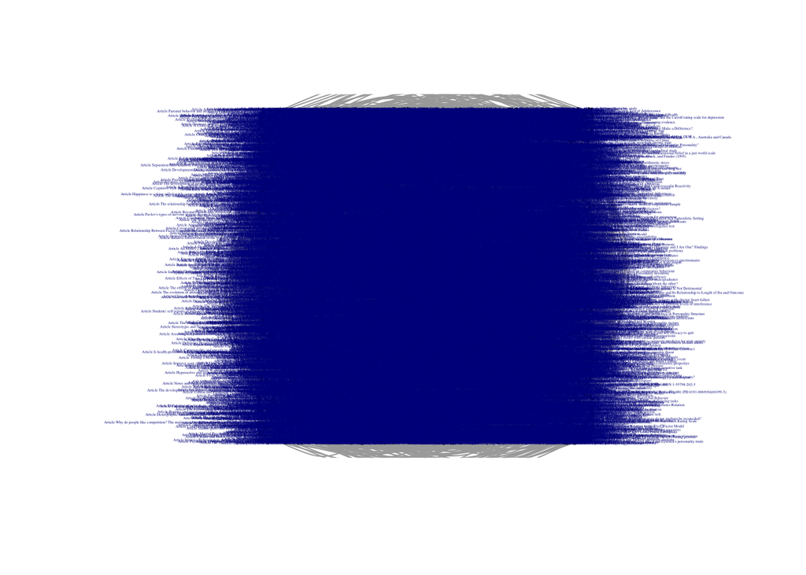

```r
plot(journal_graph, layout=layout_with_lgl, vertex.size=1, vertex.label.cex=0.2)
```

### Main Component of Graph

The main component graph contains all of the authors and articles who have some collaboration link among them. This step also identifies communities using louvain clustering. Clustering was applied to a graph containing both articles and authors so that articles will tend to be assigned membership according to the relative contributions of all co-authors.

```r
main_component_graph = get_main_component(journal_graph)
main_component_graph
```

```
## IGRAPH e2132fb U--- 4048 14240 --
## + attr: node_type (v/c), doi (v/c), issn (v/c), title (v/c), cover_date
## | (v/c), volume (v/c), abstract (v/c), journal (v/c), keywords (v/c),
## | label (v/c), author_name (v/c), scopus_id (v/c), id (v/c), membership
## | (v/n), edge_type (e/c)
## + edges from e2132fb:
##  [1]  1-- 2  1-- 3  2-- 3  2-- 3  4-- 5  4-- 6  5-- 6  5-- 6  4-- 7  5-- 7
## [11]  5-- 7  6-- 7  6-- 7  4-- 8  5-- 8  5-- 8  6-- 8  6-- 8  7-- 8  7-- 8
## [21]  4-- 9  5-- 9  5-- 9  6-- 9  6-- 9  7-- 9  7-- 9  8-- 9  8-- 9 10--11
## [31] 10--12 11--12 11--12 10--13 11--13 11--13 12--13 12--13 14--15 16--17
## [41] 16--18 17--18 17--18 19--20 19--21 20--21 20--21 22--23 17--24 17--24
## + ... omitted several edges
```

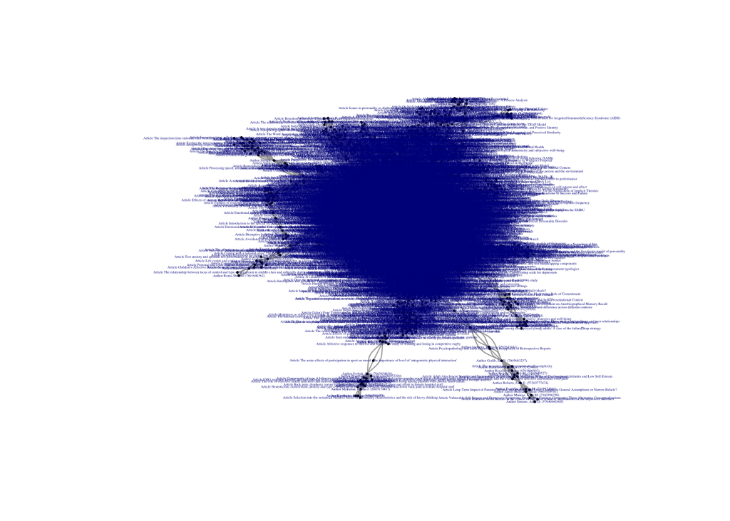

```r
plot(main_component_graph, layout=layout_with_lgl, vertex.size=1, vertex.label.cex=0.2)
```

We can inspect these graphs to verify that certain authors are present:

```r
find_author(journal_graph, "Pennebaker, James W.")
```

```
## + 1/11939 vertex, from 17cc7b3:
## [1] 2
```

```r
find_author(main_component_graph, "Pennebaker, James W.")
```

```
## + 1/4048 vertex, from e2132fb:
## [1] 2
```

### Article Communities

The resulting data frame contains the articles, along with community membership, for the main component.

```r
df_article_communities = get.data.frame(main_component_graph, what="vertices")
df_article_communities = df_article_communities[df_article_communities$node_type=="article",]
df_article_communities = df_article_communities[c("doi", "title", "issn", "abstract", "membership")]
df_article_communities$title = tolower(df_article_communities$title)

head(df_article_communities, n=1)
```

```
##                           doi
## 1 10.1037/0022-3514.77.6.1296
##                                                         title     issn
## 1 linguistic styles: language use as an individual difference 00223514
##                                                                                                                                                                                                                                                                                                          …
## 1 Can language use reflect personality style? Studies examined the reliability, factor structure, and validity of written language using a word-based, computerized text analysis program. Daily diaries from 15 substance abuse inpatients, daily writing assignments from 35 students, and journal abst…
##   membership
## 1          1
```

```r
nrow(df_article_communities)
```

```
## [1] 1971
```

## Testing for presence of expected articles

Once we’ve applied our planned the filters and transforms, we inspect the resulting data frame to ensure that certain articles are still present.

### Finding an article we expected

```r
sum(df_article_communities$title == "linguistic styles: language use as an individual difference")
```

```
## [1] 1
```

The article is in the journal_graph too.

```r
V(journal_graph)[V(journal_graph)$title == "Linguistic styles: Language use as an individual difference"]
```

```
## + 1/11939 vertex, from 17cc7b3:
## [1] 1
```

An article not present in the journal_graph looks like this:

```r
V(journal_graph)[V(journal_graph)$node_type == "article" & V(journal_graph)$title == "tHis aRtiCLe doEs NoT ExISt"]
```

```
## + 0/11939 vertices, from 17cc7b3:
```

The article **Construction of Circumplex Scales for the Inventory of Interpersonal Problems** is present in the journal_graph.

```r
V(journal_graph)[V(journal_graph)$node_type == "article" & V(journal_graph)$title == "Construction of Circumplex Scales for the Inventory of Interpersonal Problems"]
```

```
## + 1/11939 vertex, from 17cc7b3:
## [1] 5485
```

We can look at the communities df. It is also present in our final data frame.

```r
sum(df_article_communities$title == "construction of circumplex scales for the inventory of interpersonal problems")
```

```
## [1] 1
```

### Other articles that are expected in the data frame

Quite a few articles were missing - but these are all now in the data frame.

```r
sum(df_article_communities$title == "construction of circumplex scales for the inventory of interpersonal problems")
```

```
## [1] 1
```

```r
sum(df_article_communities$title == "personality trait structure as a human universal")
```

```
## [1] 1
```

```r
sum(df_article_communities$title == "evaluating stability and change in personality and depression")
```

```
## [1] 1
```

```r
sum(df_article_communities$title == "on the accuracy of personality judgment: a realistic approach")
```

```
## [1] 1
```

```r
sum(df_article_communities$title == "the divided self: concurrent and longitudinal effects of psychological adjustment and social roles on self-concept differentiation")
```

```
## [1] 1
```